# hw3

Author

Andre Gala-Garza

Published

March 27, 2026

**Disclaimer:** Generative AI was used to assist with templating and writing code in this assignment; however, this code was checked manually and edited by hand to ensure accuracy.

**Source:** OpenAI. (2026). *ChatGPT* [Large language model]. https://chatgpt.com/.

```r
library(tidyverse)
library(tidytext)
library(dplyr)
library(textdata)
```

# Exploratory Data Analysis

```r
pubmed <- read.csv("pubmed.csv")
```

```r
colnames(pubmed)
```

```
[1] "abstract" "term"
```

```r
head(pubmed$term)
```

```
[1] "covid" "covid" "covid" "covid" "covid" "covid"
```

```r
unique(pubmed$term)
```

```
[1] "covid"           "meningitis"      "prostate cancer" "cystic fibrosis"
[5] "preeclampsia"
```

```r
head(pubmed$abstract)
```

```
[1] "Background and aims: Many patients with coronavirus disease 2019 (COVID-19) have underlying cardiovascular (CV) disease or develop acute cardiac injury during the course of the illness. Adequate understanding of the interplay between COVID-19 and CV disease is required for optimum management of…
[2] "Introduction: Contradictory data have been reported on the incidence of stroke in patients with COVID-19 and the risk of SARS-CoV-2 infection among patients with history of stroke. Methods: This study systematically reviews case series reporting stroke as a complication of COVID-19, and analyse…
[3] "This article aims at collecting all information needed for dentists regarding the COVID-19 pandemic throughout the world by reviewing articles published by now. In late 2019, a pneumonia outbreak of uncertain etiology happened in Wuhan, China. There were many reports related to a live-animal an…
[4] "OBJECTIVE. The objective of our study was to determine the misdiagnosis rate of radiologists for coronavirus disease 2019 (COVID-19) and evaluate the performance of chest CT in the diagnosis and management of COVID-19. The CT features of COVID-19 are reported and compared with the CT features o…
[5] "Background: Much of the focus regarding the global pandemic of coronavirus disease of 2019 (COVID-19) has been on the cardiovascular, pulmonary, and hematologic complications. However, neurologic complications have arisen as an increasingly recognized area of morbidity and mortality. Objective:…
[6] "The World Health Organization (WHO) has issued a warning that, although the 2019 novel coronavirus (COVID-19) from Wuhan City (China), is not pandemic, it should be contained to prevent the global spread. The COVID-19 virus was known earlier as 2019-nCoV. As of 12 February 2020, WHO reported 45…
```

# Text Mining

## Problem 1

```r
# Number of articles per search term
pubmed %>%
  count(term, sort = TRUE)
```

```
             term   n
1           covid 981
2 prostate cancer 787
3    preeclampsia 780
4 cystic fibrosis 376
5      meningitis 317
```

From this frequency table, we see that “covid” is the search term with the most articles, followed by “prostate cancer” and “preeclampsia”. Meanwhile, “cystic fibrosis” and “meningitis” have significantly fewer search results.

```r
# Most common tokens overall
pubmed %>%
  unnest_tokens(token, abstract) %>%
  count(token, sort = TRUE) %>%
  head(10)
```

```
   token     n
1    the 28126
2     of 24760
3    and 19993
4     in 14653
5     to 10920
6      a  8245
7   with  8038
8  covid  7275
9     19  7080
10    is  5649
```

From this table, we see that nearly all of the most common tokens are stopwords like “and”, “the”, or “of”, which do not provide significant meaning. The most common tokens that are not stopwords are “covid” and “19”, highlighting the impact of the COVID-19 pandemic on the content of PubMed articles.

```r
# 5 most common tokens per search term
pubmed %>%
  unnest_tokens(token, abstract, drop = FALSE) %>%
  count(term, token, sort = TRUE) %>%
  group_by(term) %>%
  slice_max(n, n = 5, with_ties = FALSE) %>%
  ungroup()
```

```
# A tibble: 25 × 3
   term            token        n
   <chr>           <chr>    <int>
 1 covid           the       9741
 2 covid           of        7668
 3 covid           covid     7275
 4 covid           19        7035
 5 covid           and       6861
 6 cystic fibrosis the       2677
 7 cystic fibrosis of        2304
 8 cystic fibrosis and       1777
 9 cystic fibrosis in        1497
10 cystic fibrosis to        1011
11 meningitis      the       2489
12 meningitis      of        2269
13 meningitis      and       1683
14 meningitis      in        1322
15 meningitis      a          830
16 preeclampsia    the       7119
17 preeclampsia    of        6837
18 preeclampsia    and       5255
19 preeclampsia    in        3869
20 preeclampsia    to        2651
21 prostate cancer the       6100
22 prostate cancer of        5682
23 prostate cancer and       4417
24 prostate cancer cancer    3840
25 prostate cancer prostate  3832
```

From viewing the 5 most common tokens per search term, we see that all of them are stopwords except for “covid” and “19” for the search term “covid”, and “cancer” and “prostate” for the search term “prostate cancer”.

## Problem 2

```r
# Most common tokens while removing stop words
pubmed %>%
  unnest_tokens(token, abstract) %>%
  anti_join(stop_words, by = c("token" = "word")) %>%
  count(token, sort = TRUE) %>%
  head(10)
```

```
          token    n
1         covid 7275
2            19 7080
3      patients 4674
4        cancer 3999
5      prostate 3832
6       disease 2574
7           pre 2165
8     eclampsia 2005
9  preeclampsia 1863
10    treatment 1841
```

After removing stopwords, we now find that the most common tokens are much more closely related to the search terms themselves, such as “covid”, “cancer”, “prostate”, and “preeclampsia”. We also see that “disease” and “treatment” are very common tokens, which make sense because those concepts can be applied to nearly any medical case.

## Problem 3

```r
# Tokenize abstracts into bigrams
bigrams <- pubmed %>%
  unnest_tokens(bigram, abstract, token = "ngrams", n = 2)

# 10 most common bigrams
top_bigrams <- bigrams %>%
  count(bigram, sort = TRUE) %>%
  head(10)

top_bigrams
```

```
            bigram    n
1         covid 19 6969
2           of the 3883
3           in the 3418
4  prostate cancer 3222
5    pre eclampsia 1854
6    patients with 1587
7         of covid 1519
8          and the 1154
9           to the 1061
10     of prostate  870
```

When including stopwords in the abstracts, we find that the most common bigram is “covid 19” (further demonstrating the impact of the COVID-19 pandemic on the content of abstracts), followed by two stopword bigrams, then “prostate cancer” and “pre eclampsia”.

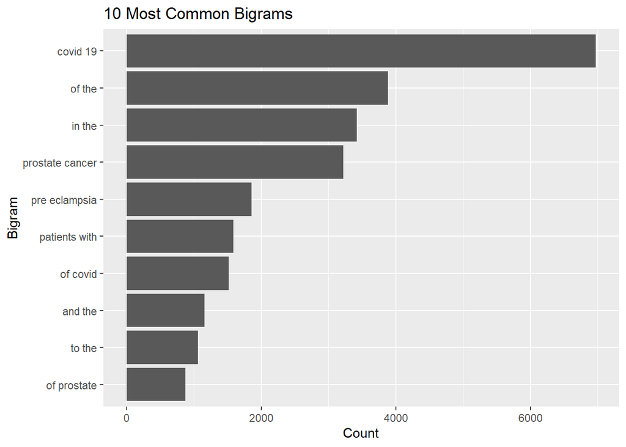

```r
# Visualize the 10 most common bigrams
top_bigrams %>%
  ggplot(aes(x = reorder(bigram, n), y = n)) +
  geom_col() +
  coord_flip() +
  labs(x = "Bigram", y = "Count", title = "10 Most Common Bigrams")
```

## Problem 4

```r
# Calculate TF-IDF for each token within each search term
tf_idf_words <- pubmed %>%
  unnest_tokens(token, abstract) %>%
  anti_join(stop_words, by = c("token" = "word")) %>%
  count(term, token, sort = TRUE) %>%
  bind_tf_idf(token, term, n)

head(tf_idf_words)
```

```
             term    token    n         tf      idf     tf_idf
1           covid    covid 7275 0.06468852 1.609438 0.10411215
2           covid       19 7035 0.06255446 0.000000 0.00000000
3 prostate cancer   cancer 3840 0.05641169 0.000000 0.00000000
4 prostate cancer prostate 3832 0.05629416 1.609438 0.09060196
5           covid patients 2293 0.02038911 0.000000 0.00000000
6    preeclampsia      pre 2038 0.02594889 0.000000 0.00000000
```

```r
# 5 tokens with the highest TF-IDF for each search term
tf_idf_words %>%
  group_by(term) %>%
  slice_max(tf_idf, n = 5, with_ties = FALSE) %>%
  ungroup() %>%
  arrange(term, desc(tf_idf))
```

```
# A tibble: 25 × 6
   term            token               n      tf   idf  tf_idf
   <chr>           <chr>           <int>   <dbl> <dbl>   <dbl>
 1 covid           covid            7275 0.0647  1.61  0.104
 2 covid           pandemic          800 0.00711 1.61  0.0114
 3 covid           coronavirus       647 0.00575 1.61  0.00926
 4 covid           sars              372 0.00331 1.61  0.00532
 5 covid           cov               334 0.00297 1.61  0.00478
 6 cystic fibrosis cf                625 0.0234  0.916 0.0215
 7 cystic fibrosis fibrosis          867 0.0325  0.511 0.0166
 8 cystic fibrosis cystic            862 0.0323  0.511 0.0165
 9 cystic fibrosis cftr               86 0.00322 1.61  0.00518
10 cystic fibrosis sweat              83 0.00311 1.61  0.00500
11 meningitis      meningitis        429 0.0164  1.61  0.0264
12 meningitis      meningeal         219 0.00837 1.61  0.0135
13 meningitis      pachymeningitis   149 0.00569 1.61  0.00916
14 meningitis      csf               206 0.00787 0.916 0.00721
15 meningitis      meninges          106 0.00405 1.61  0.00652
16 preeclampsia    eclampsia        2005 0.0255  1.61  0.0411
17 preeclampsia    preeclampsia     1863 0.0237  1.61  0.0382
18 preeclampsia    pregnancy         969 0.0123  0.511 0.00630
19 preeclampsia    maternal          797 0.0101  0.511 0.00518
20 preeclampsia    gestational       191 0.00243 1.61  0.00391
21 prostate cancer prostate         3832 0.0563  1.61  0.0906
22 prostate cancer androgen          305 0.00448 1.61  0.00721
23 prostate cancer psa               282 0.00414 1.61  0.00667
24 prostate cancer prostatectomy     215 0.00316 1.61  0.00508
25 prostate cancer castration        148 0.00217 1.61  0.00350
```

The TF-IDF evaluates how important each word in the abstract is to the “document” (the search term). The results in Question 1 instead only tally the frequency of each word for each search term.

The Question 1 results are dominated by very common words such as “the,” “of,” “and,” and “in”; these appear often in every set of abstracts, but do not tell us much about what makes each search term distinctive. By contrast, the TF-IDF results highlight words that are especially characteristic of each search term relative to the others: for example, “covid,” “pandemic,” and “coronavirus” stand out for the covid abstracts, while “cf,” “cftr,” and “sweat” are more specific to cystic fibrosis, and “meningitis,” “meningeal,” and “meninges” are more specific to meningitis. Similarly, “eclampsia” and “preeclampsia” stand out for preeclampsia, and “prostate,” “psa,” and “prostatectomy” stand out for prostate cancer. Overall, the Question 1 results shows the most repeated words, while TF-IDF is more useful for identifying the words that best distinguish one topic from another.

# Sentiment Analysis

## Problem 5

```r
# Sentiment analysis with NRC lexicon
nrc_sentiments <- pubmed %>%
  unnest_tokens(token, abstract) %>%
  inner_join(get_sentiments("nrc"), by = c("token" = "word"))
# Most common sentiment for each search term
nrc_sentiments %>%
  count(term, sentiment, sort = TRUE) %>%
  group_by(term) %>%
  slice_max(n, n = 1, with_ties = FALSE) %>%
  ungroup()
```

```
# A tibble: 5 × 3
  term            sentiment     n
  <chr>           <chr>     <int>
1 covid           positive   9874
2 cystic fibrosis positive   2747
3 meningitis      negative   2111
4 preeclampsia    positive   8014
5 prostate cancer negative   8918
```

With all NRC categories included, covid, cystic fibrosis, and preeclampsia are dominated by “positive,” while meningitis and prostate cancer are dominated by “negative,” which gives a broad sense of tone but not much detail.

```r
# Most common sentiment for each search term,
# removing "positive" and "negative"
nrc_sentiments %>%
  filter(!sentiment %in% c("positive", "negative")) %>%
  count(term, sentiment, sort = TRUE) %>%
  group_by(term) %>%
  slice_max(n, n = 1, with_ties = FALSE) %>%
  ungroup()
```

```
# A tibble: 5 × 3
  term            sentiment        n
  <chr>           <chr>        <int>
1 covid           fear          7730
2 cystic fibrosis disgust       1714
3 meningitis      fear          1510
4 preeclampsia    anticipation  4780
5 prostate cancer fear          8118
```

After removing those two general categories, more specific emotional patterns appear: covid, meningitis, and prostate cancer are most associated with “fear,” which makes sense given their seriousness and risk; preeclampsia is most associated with “anticipation,” possibly reflecting monitoring, prediction, and prevention in pregnancy care; and cystic fibrosis is most associated with “disgust,” likely because of how certain disease-related terms are classified in the NRC lexicon rather than because the abstracts are written in an emotional style.

## Problem 6

```r
# Create an abstract ID
pubmed <- pubmed %>%
  mutate(abstract_id = row_number())

# Get average AFINN sentiment score for each abstract
afinn <- lexicon_afinn()

afinn_scores <- pubmed %>%
  unnest_tokens(token, abstract) %>%
  inner_join(afinn, by = c("token" = "word")) %>%
  group_by(term, abstract_id) %>%
  summarize(avg_score = mean(value), .groups = "drop")

head(afinn_scores)
```

```
# A tibble: 6 × 3
  term  abstract_id avg_score
  <chr>       <int>     <dbl>
1 covid           1    -1.13
2 covid           2    -2
3 covid           3     0.214
4 covid           4    -0.8
5 covid           5    -1.67
6 covid           6    -0.143
```

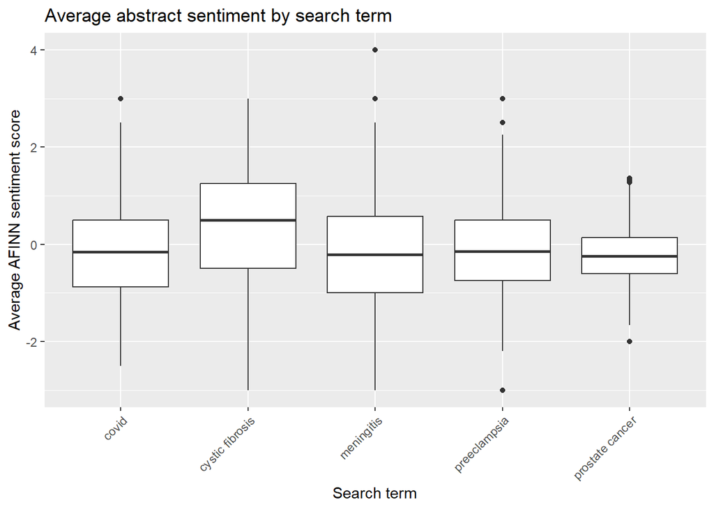

```r
# Visualize average abstract sentiment scores by search term
afinn_scores %>%
  ggplot(aes(x = term, y = avg_score)) +
  geom_boxplot() +
  labs(
    x = "Search term",
    y = "Average AFINN sentiment score",
    title = "Average abstract sentiment by search term"
  ) +
  theme(axis.text.x = element_text(angle = 45, hjust = 1))
```

The search terms do not appear to be dramatically different overall, since most of the boxplots are centered near zero and have substantial overlap. That suggests the average sentiment of the abstracts is fairly similar across topics. The main exception is cystic fibrosis, which has a noticeably higher median AFINN score than the others, indicating its abstracts tend to be somewhat more positive on average. In contrast, covid, meningitis, preeclampsia, and prostate cancer all have medians that are slightly below zero or close to neutral, with fairly similar spreads. There are also outliers for several terms, showing that some individual abstracts are much more positive or negative than the typical abstract, but these extreme values do not seem to change the overall pattern very much.